# notebook-for-answers

```python
## import ....
import pandas as pd
import numpy as np
import matplotlib.pyplot as plt
import seaborn as sns

#VAT algorithm provided for your use
def VAT(R):
    """

    VAT algorithm adapted from matlab version:
    http://www.ece.mtu.edu/~thavens/code/VAT.m

    Args:
        R (n*n double): Dissimilarity data input
        R (n*D double): vector input (R is converted to sq. Euclidean distance)
    Returns:
        RV (n*n double): VAT-reordered dissimilarity data
        C (n int): Connection indexes of MST in [0,n)
        I (n int): Reordered indexes of R, the input data in [0,n)
    """

    R = np.array(R)
    N, M = R.shape
    if N != M:
        R = squareform(pdist(R))

    J = list(range(0, N))

    y = np.max(R, axis=0)
    i = np.argmax(R, axis=0)
    j = np.argmax(y)
    y = np.max(y)


    I = i[j]
    del J[I]

    y = np.min(R[I,J], axis=0)
    j = np.argmin(R[I,J], axis=0)

    I = [I, J[j]]
    J = [e for e in J if e != J[j]]

    C = [1,1]
    for r in range(2, N-1):
        y = np.min(R[I,:][:,J], axis=0)
        i = np.argmin(R[I,:][:,J], axis=0)
        j = np.argmin(y)
        y = np.min(y)
        I.extend([J[j]])
        J = [e for e in J if e != J[j]]
        C.extend([i[j]])

    y = np.min(R[I,:][:,J], axis=0)
    i = np.argmin(R[I,:][:,J], axis=0)

    I.extend(J)
    C.extend(i)

    RI = list(range(N))
    for idx, val in enumerate(I):
        RI[val] = idx

    RV = R[I,:][:,I]

    return RV.tolist(), C, I
```

```python
#begin answering questions.  Please start a new cell for each question.

df_traffic = pd.read_csv('traffic.csv')
df_traffic.head()
```

|  | date | road_name | location | suburb | speed_limit | direction | time | vehicle_class_1 | vehicle_class_2 | vehicle_class_3 | ... | vehicle_class_12 | vehicle_class_13 | motorcycle | bike | average_speed | 85th_percentile_speed | maximum_speed | road_segment | road_segment_1 | road_segment_2 |
| --- | --- | --- | --- | --- | --- | --- | --- | --- | --- | --- | --- | --- | --- | --- | --- | --- | --- | --- | --- | --- | --- |
| 0 | 3/09/2015 | Bayles Street | Between Fitzgibbon Street and Jageurs Lane | Parkville | 40 | E | 0:00 | 0.0 | 0.0 | 0.0 | ... | 0.0 | 0.0 | 0.0 | 0.0 | 0.0 | 0.0 | - | 22353 | NaN | NaN |
| 1 | 3/09/2015 | Bayles Street | Between Fitzgibbon Street and Jageurs Lane | Parkville | 40 | E | 1:00 | 0.0 | 0.0 | 0.0 | ... | 0.0 | 0.0 | 0.0 | 0.0 | 0.0 | 0.0 | - | 22353 | NaN | NaN |
| 2 | 3/09/2015 | Bayles Street | Between Fitzgibbon Street and Jageurs Lane | Parkville | 40 | E | 2:00 | 0.0 | 0.0 | 0.0 | ... | 0.0 | 0.0 | 0.0 | 0.0 | 0.0 | 0.0 | - | 22353 | NaN | NaN |
| 3 | 3/09/2015 | Bayles Street | Between Fitzgibbon Street and Jageurs Lane | Parkville | 40 | E | 3:00 | 0.0 | 0.0 | 0.0 | ... | 0.0 | 0.0 | 0.0 | 0.0 | 0.0 | 0.0 | - | 22353 | NaN | NaN |
| 4 | 3/09/2015 | Bayles Street | Between Fitzgibbon Street and Jageurs Lane | Parkville | 40 | E | 4:00 | 1.0 | 0.0 | 0.0 | ... | 0.0 | 0.0 | 0.0 | 1.0 | 18.2 | 18.0 | 18 | 22353 | NaN | NaN |

5 rows × 28 columns

# Stage 1: Understand the dataset

To begin, we would like to understand the characterisitcs of the dataset we are working with. We would also like to clean the dataset by removing malformed or missing entries that will make analysis more difficult.

### Q1. Print the number of traffic survey entries, number of attributes, attribute names and their data types from traffic.csv dataset

```python
df_traffic.info()
```

```
<class 'pandas.core.frame.DataFrame'>
RangeIndex: 60168 entries, 0 to 60167
Data columns (total 28 columns):
date                     60168 non-null object
road_name                60168 non-null object
location                 60168 non-null object
suburb                   60168 non-null object
speed_limit              60168 non-null int64
direction                60168 non-null object
time                     60168 non-null object
vehicle_class_1          60056 non-null float64
vehicle_class_2          60056 non-null float64
vehicle_class_3          60056 non-null float64
vehicle_class_4          60056 non-null float64
vehicle_class_5          60056 non-null float64
vehicle_class_6          60056 non-null float64
vehicle_class_7          60056 non-null float64
vehicle_class_8          60056 non-null float64
vehicle_class_9          60056 non-null float64
vehicle_class_10         60056 non-null float64
vehicle_class_11         60056 non-null float64
vehicle_class_12         60056 non-null float64
vehicle_class_13         60056 non-null float64
motorcycle               44912 non-null float64
bike                     44912 non-null float64
average_speed            55160 non-null float64
85th_percentile_speed    55159 non-null float64
maximum_speed            45144 non-null object
road_segment             60168 non-null int64
road_segment_1           5040 non-null float64
road_segment_2           4032 non-null float64
dtypes: float64(19), int64(2), object(7)
memory usage: 12.9+ MB
```

### Q1.2

#### A number of survey entries detected no vehicles of any type. For some of these entries, a maximum speed of '-' has been included. For others, the maximum speed is blank. Create a Dataframe traffic from traffic.csv datasets with all such entries removed and print the numbers of remaining traffic survey entries.

```python
traffic = df_traffic.copy()
traffic.head()
```

|  | date | road_name | location | suburb | speed_limit | direction | time | vehicle_class_1 | vehicle_class_2 | vehicle_class_3 | ... | vehicle_class_12 | vehicle_class_13 | motorcycle | bike | average_speed | 85th_percentile_speed | maximum_speed | road_segment | road_segment_1 | road_segment_2 |
| --- | --- | --- | --- | --- | --- | --- | --- | --- | --- | --- | --- | --- | --- | --- | --- | --- | --- | --- | --- | --- | --- |
| 0 | 3/09/2015 | Bayles Street | Between Fitzgibbon Street and Jageurs Lane | Parkville | 40 | E | 0:00 | 0.0 | 0.0 | 0.0 | ... | 0.0 | 0.0 | 0.0 | 0.0 | 0.0 | 0.0 | - | 22353 | NaN | NaN |
| 1 | 3/09/2015 | Bayles Street | Between Fitzgibbon Street and Jageurs Lane | Parkville | 40 | E | 1:00 | 0.0 | 0.0 | 0.0 | ... | 0.0 | 0.0 | 0.0 | 0.0 | 0.0 | 0.0 | - | 22353 | NaN | NaN |
| 2 | 3/09/2015 | Bayles Street | Between Fitzgibbon Street and Jageurs Lane | Parkville | 40 | E | 2:00 | 0.0 | 0.0 | 0.0 | ... | 0.0 | 0.0 | 0.0 | 0.0 | 0.0 | 0.0 | - | 22353 | NaN | NaN |
| 3 | 3/09/2015 | Bayles Street | Between Fitzgibbon Street and Jageurs Lane | Parkville | 40 | E | 3:00 | 0.0 | 0.0 | 0.0 | ... | 0.0 | 0.0 | 0.0 | 0.0 | 0.0 | 0.0 | - | 22353 | NaN | NaN |
| 4 | 3/09/2015 | Bayles Street | Between Fitzgibbon Street and Jageurs Lane | Parkville | 40 | E | 4:00 | 1.0 | 0.0 | 0.0 | ... | 0.0 | 0.0 | 0.0 | 1.0 | 18.2 | 18.0 | 18 | 22353 | NaN | NaN |

5 rows × 28 columns

```python
traffic.tail()
```

|  | date | road_name | location | suburb | speed_limit | direction | time | vehicle_class_1 | vehicle_class_2 | vehicle_class_3 | ... | vehicle_class_12 | vehicle_class_13 | motorcycle | bike | average_speed | 85th_percentile_speed | maximum_speed | road_segment | road_segment_1 | road_segment_2 |
| --- | --- | --- | --- | --- | --- | --- | --- | --- | --- | --- | --- | --- | --- | --- | --- | --- | --- | --- | --- | --- | --- |
| 60163 | 13/11/2014 | Wolseley Parade | North East of Derby Street | Kensington | 50 | W | 19:00 | 16.0 | 0.0 | 0.0 | ... | 0.0 | 0.0 | NaN | NaN | 30.4 | 36.0 | NaN | 21727 | NaN | NaN |
| 60164 | 13/11/2014 | Wolseley Parade | North East of Derby Street | Kensington | 50 | W | 20:00 | 19.0 | 0.0 | 0.0 | ... | 0.0 | 0.0 | NaN | NaN | 33.7 | 40.2 | NaN | 21727 | NaN | NaN |
| 60165 | 13/11/2014 | Wolseley Parade | North East of Derby Street | Kensington | 50 | W | 21:00 | 13.0 | 0.0 | 0.0 | ... | 0.0 | 0.0 | NaN | NaN | 31.1 | 37.0 | NaN | 21727 | NaN | NaN |
| 60166 | 13/11/2014 | Wolseley Parade | North East of Derby Street | Kensington | 50 | W | 22:00 | 23.0 | 0.0 | 0.0 | ... | 0.0 | 0.0 | NaN | NaN | 30.7 | 36.0 | NaN | 21727 | NaN | NaN |
| 60167 | 13/11/2014 | Wolseley Parade | North East of Derby Street | Kensington | 50 | W | 23:00 | 6.0 | 0.0 | 0.0 | ... | 0.0 | 0.0 | NaN | NaN | 33.4 | 38.0 | NaN | 21727 | NaN | NaN |

5 rows × 28 columns

```python
traffic['maximum_speed'].str.contains('-').sum()
```

```
3634
```

#### Here, we know that the number of entries in maximum speed feature that has '-' included is 3634

```python
traffic['maximum_speed'].isnull().sum()
```

```
15024
```

#### Drop both '-' and null values in maximum speed feature

```python
traffic.drop(traffic[traffic['maximum_speed'] == '-' ].index, inplace = True)
```

```python
traffic.drop(traffic[traffic['maximum_speed'].isnull()].index, inplace = True)
```

#### Test: Check if all the '-' and null values in maximum speed feature has been dropped

```python
traffic['maximum_speed'].isnull().sum()
```

```
0
```

```python
traffic['maximum_speed'].str.contains('-').sum()
```

```
0
```

#### This means all the values has been removed

```python
traffic.info()
```

```
<class 'pandas.core.frame.DataFrame'>
Int64Index: 41510 entries, 4 to 49529
Data columns (total 28 columns):
date                     41510 non-null object
road_name                41510 non-null object
location                 41510 non-null object
suburb                   41510 non-null object
speed_limit              41510 non-null int64
direction                41510 non-null object
time                     41510 non-null object
vehicle_class_1          41510 non-null float64
vehicle_class_2          41510 non-null float64
vehicle_class_3          41510 non-null float64
vehicle_class_4          41510 non-null float64
vehicle_class_5          41510 non-null float64
vehicle_class_6          41510 non-null float64
vehicle_class_7          41510 non-null float64
vehicle_class_8          41510 non-null float64
vehicle_class_9          41510 non-null float64
vehicle_class_10         41510 non-null float64
vehicle_class_11         41510 non-null float64
vehicle_class_12         41510 non-null float64
vehicle_class_13         41510 non-null float64
motorcycle               41379 non-null float64
bike                     41379 non-null float64
average_speed            41510 non-null float64
85th_percentile_speed    41509 non-null float64
maximum_speed            41510 non-null object
road_segment             41510 non-null int64
road_segment_1           3557 non-null float64
road_segment_2           2885 non-null float64
dtypes: float64(19), int64(2), object(7)
memory usage: 9.2+ MB
```

#### Hence, we know that the number of remaining traffic survey entries is 41510 entries

### Q1.3

### The vehicle_class_1 attribute represents the number of short vehicles such as cars, detected in a survey hour. Using Traffic DataFrame (from Q1.2) find,

- What is the median value of vehicle_class_1?
- What is the highest maximum_speed detected across all survey entries? Your code should print out the results with the following format: where # is rounded to 1 decimal place

```python
traffic['vehicle_class_1'].median()
```

```
28.0
```

#### Median value of vehicle class_1: 28.0

```python
traffic['vehicle_class_1'].max()
```

```
1954.0
```

```python
traffic[traffic['vehicle_class_1'] == 1954]['maximum_speed']
```

```
39067    66
Name: maximum_speed, dtype: object
```

```python
traffic['vehicle_class_2'].max()
```

```
139.0
```

```python
traffic['vehicle_class_3'].max()
```

```
165.0
```

```python
traffic['maximum_speed'].max()
```

```
'99'
```

Check the entire features in the dataframe to spot if there are any wrong datatypes

```python
traffic.dtypes
```

```
date                      object
road_name                 object
location                  object
suburb                    object
speed_limit                int64
direction                 object
time                      object
vehicle_class_1          float64
vehicle_class_2          float64
vehicle_class_3          float64
vehicle_class_4          float64
vehicle_class_5          float64
vehicle_class_6          float64
vehicle_class_7          float64
vehicle_class_8          float64
vehicle_class_9          float64
vehicle_class_10         float64
vehicle_class_11         float64
vehicle_class_12         float64
vehicle_class_13         float64
motorcycle               float64
bike                     float64
average_speed            float64
85th_percentile_speed    float64
maximum_speed             object
road_segment               int64
road_segment_1           float64
road_segment_2           float64
dtype: object
```

Change the datatype of maximum_speed feature into integer

```python
traffic['maximum_speed'] = traffic['maximum_speed'].astype(int)
```

```python
traffic['maximum_speed'].max()
```

```
159
```

#### Highest value of maximum_speed: 159

Test: Check if the datatype of maximum_speed feature has changed

```python
traffic['maximum_speed'].dtypes
```

```
dtype('int64')
```

## Stage 2: Data Selection & Manipulation

#### We are particularly interested in understanding traffic patterns across different types of roads. While the traffic.csv files does not contain any information about the type of road a survey entry is related too, this information is contained in the datasets roads.json. We can map the road_segment attribute from the traffic DataFrame with the SegID attribute in the roads JSON dataset to discover which type of road a particular survey entry is related to.

### Q 2.1

### Using the traffic DataFrame as well as roads.json, add the attribute StrType from the JSON dataset to the traffic DataFrame. Print the first 3 rows.

Open the file to read the data in JSON format

```python
import json
file = open('roads.json', 'r')
text = file.read()
text = json.loads(text)
text
```

[output not shown]

[output cut: 18349 more lines]

[output not shown]

Get the ID of the road

```python
keys = []
for i in range(0, len(text['data'])):
    keys.append(text['data'][i][9])
```

```python
keys[:10]
```

```
['20635',
 '22519',
 '22420',
 '30082',
 '22902',
 '20268',
 '22517',
 '30162',
 '20471',
 '30522']
```

```python
len(keys)
```

```
4184
```

Get the Street Type

```python
values = []
for i in range(0, len(text['data'])):
    values.append(text['data'][i][14])
```

```python
values[:10]
```

```
['Arterial',
 'Council Major',
 'Council Minor',
 'Rail/Tram',
 'Council Minor',
 'Council Minor',
 'Council Major',
 'Private',
 'Council Major',
 'Private']
```

```python
len(values)
```

```
4184
```

Create a dictionary to map the road ID to the Street Type

```python
key_value_pair = {}
for i in range(0, len(text['data'])):
    key = text['data'][i][9]
    value = text['data'][i][14]
    key_value_pair[key] = value
```

```python
key_value_pair
```

[output not shown]

[output cut: 946 more lines]

[output not shown]

Check individual key-value pair

```python
print(key_value_pair['22353'])
```

```
Council Major
```

```python
for i in key_value_pair:
    if i == '22353':
        print(key_value_pair[i])
```

```
Council Major
```

Create two lists to mirror the road_segment feature in the traffic dataset and add the Streetype for merging later

```python
list_of_road_segment = []
list_of_strtype = []
for i in traffic['road_segment']:
    for j in key_value_pair:
        if j == str(i):
            list_of_road_segment.append(str(i))
            list_of_strtype.append(key_value_pair[j])
```

Check if the road_ID is the same as the data in the road_segment feature in the traffic dataset

```python
list_of_road_segment[:9]
```

```
['22353',
 '22353',
 '22353',
 '22353',
 '22353',
 '22353',
 '22353',
 '22353',
 '22353']
```

Check if the street type is the same as the road_ID

```python
list_of_strtype[:9]
```

```
['Council Major',
 'Council Major',
 'Council Major',
 'Council Major',
 'Council Major',
 'Council Major',
 'Council Major',
 'Council Major',
 'Council Major']
```

Create a dictionary that looks like a dataframe with features : road_segment and StrType

```python
road_segment_strtype_dict = {}
road_segment_strtype_dict['road_segment'] = list_of_road_segment
road_segment_strtype_dict['StrType'] = list_of_strtype
road_segment_strtype_dict
```

[output not shown]

[output cut: 1947 more lines]

[output not shown]

Convert the dictionary into a dataframe

```python
road_segment_strtype_df = pd.DataFrame(road_segment_strtype_dict)
road_segment_strtype_df.head(5)
```

|  | road_segment | StrType |
| --- | --- | --- |
| 0 | 22353 | Council Major |
| 1 | 22353 | Council Major |
| 2 | 22353 | Council Major |
| 3 | 22353 | Council Major |
| 4 | 22353 | Council Major |

Check the datatypes and the number of entries in the newly created dataframe

```python
road_segment_strtype_df.info()
```

```
<class 'pandas.core.frame.DataFrame'>
RangeIndex: 41510 entries, 0 to 41509
Data columns (total 2 columns):
road_segment    41510 non-null object
StrType         41510 non-null object
dtypes: object(2)
memory usage: 648.7+ KB
```

```python
traffic['road_segment'].dtypes
```

```
dtype('int64')
```

Convert the datatypes of road_segment feature into integer

```python
road_segment_strtype_df['road_segment'] = road_segment_strtype_df['road_segment'].astype('int64')
```

```python
road_segment_strtype_df['road_segment'].dtypes
```

```
dtype('int64')
```

```python
road_segment_strtype_df.info()
```

```
<class 'pandas.core.frame.DataFrame'>
RangeIndex: 41510 entries, 0 to 41509
Data columns (total 2 columns):
road_segment    41510 non-null int64
StrType         41510 non-null object
dtypes: int64(1), object(1)
memory usage: 648.7+ KB
```

#### Merge and dataframe and show the first three rows of traffic Dataframe with the attribute StrType

```python
traffic = pd.merge(traffic,road_segment_strtype_df , on = 'road_segment')
traffic.head(3)
```

|  | date | road_name | location | suburb | speed_limit | direction | time | vehicle_class_1 | vehicle_class_2 | vehicle_class_3 | ... | vehicle_class_13 | motorcycle | bike | average_speed | 85th_percentile_speed | maximum_speed | road_segment | road_segment_1 | road_segment_2 | StrType |
| --- | --- | --- | --- | --- | --- | --- | --- | --- | --- | --- | --- | --- | --- | --- | --- | --- | --- | --- | --- | --- | --- |
| 0 | 3/09/2015 | Bayles Street | Between Fitzgibbon Street and Jageurs Lane | Parkville | 40 | E | 4:00 | 1.0 | 0.0 | 0.0 | ... | 0.0 | 0.0 | 1.0 | 18.2 | 18.0 | 18 | 22353 | NaN | NaN | Council Major |
| 1 | 3/09/2015 | Bayles Street | Between Fitzgibbon Street and Jageurs Lane | Parkville | 40 | E | 4:00 | 1.0 | 0.0 | 0.0 | ... | 0.0 | 0.0 | 1.0 | 18.2 | 18.0 | 18 | 22353 | NaN | NaN | Council Major |
| 2 | 3/09/2015 | Bayles Street | Between Fitzgibbon Street and Jageurs Lane | Parkville | 40 | E | 4:00 | 1.0 | 0.0 | 0.0 | ... | 0.0 | 0.0 | 1.0 | 18.2 | 18.0 | 18 | 22353 | NaN | NaN | Council Major |

3 rows × 29 columns

### Q 2.2

#### We would now like to understand which roads have the most serious incidents of speeding. Add a new attribute max speed over limit to traffic DataFrame. This column should represent the difference between the maximum speed and the speed limit attributes; that is

#### max speed over limit = maximum speed- speed limit

```python
traffic.info()
```

```
<class 'pandas.core.frame.DataFrame'>
Int64Index: 15522814 entries, 0 to 15522813
Data columns (total 29 columns):
date                     object
road_name                object
location                 object
suburb                   object
speed_limit              int64
direction                object
time                     object
vehicle_class_1          float64
vehicle_class_2          float64
vehicle_class_3          float64
vehicle_class_4          float64
vehicle_class_5          float64
vehicle_class_6          float64
vehicle_class_7          float64
vehicle_class_8          float64
vehicle_class_9          float64
vehicle_class_10         float64
vehicle_class_11         float64
vehicle_class_12         float64
vehicle_class_13         float64
motorcycle               float64
bike                     float64
average_speed            float64
85th_percentile_speed    float64
maximum_speed            int64
road_segment             int64
road_segment_1           float64
road_segment_2           float64
StrType                  object
dtypes: float64(19), int64(3), object(7)
memory usage: 3.5+ GB
```

Get the maximum speed over limit and create a new feature to store the calculated result

```python
traffic = traffic.assign(max_speed_over_limit = traffic['maximum_speed'] - traffic['speed_limit'])
```

#### The first three rows of traffic DataFrame with the new max_speeed_over_limit attribute attribute are

```python
traffic.head(3)
```

|  | date | road_name | location | suburb | speed_limit | direction | time | vehicle_class_1 | vehicle_class_2 | vehicle_class_3 | ... | motorcycle | bike | average_speed | 85th_percentile_speed | maximum_speed | road_segment | road_segment_1 | road_segment_2 | StrType | max_speed_over_limit |
| --- | --- | --- | --- | --- | --- | --- | --- | --- | --- | --- | --- | --- | --- | --- | --- | --- | --- | --- | --- | --- | --- |
| 0 | 3/09/2015 | Bayles Street | Between Fitzgibbon Street and Jageurs Lane | Parkville | 40 | E | 4:00 | 1.0 | 0.0 | 0.0 | ... | 0.0 | 1.0 | 18.2 | 18.0 | 18 | 22353 | NaN | NaN | Council Major | -22 |
| 1 | 3/09/2015 | Bayles Street | Between Fitzgibbon Street and Jageurs Lane | Parkville | 40 | E | 4:00 | 1.0 | 0.0 | 0.0 | ... | 0.0 | 1.0 | 18.2 | 18.0 | 18 | 22353 | NaN | NaN | Council Major | -22 |
| 2 | 3/09/2015 | Bayles Street | Between Fitzgibbon Street and Jageurs Lane | Parkville | 40 | E | 4:00 | 1.0 | 0.0 | 0.0 | ... | 0.0 | 1.0 | 18.2 | 18.0 | 18 | 22353 | NaN | NaN | Council Major | -22 |

3 rows × 30 columns

### Q 2.3

#### We are particularly concerned with instances of speeding on arterial roads, as arterial roads are the responsibility of VicRoads rather than local councils.

Create a new DataFrame, arterials, which contains only the survey entries from traffic that relate to Arterial roads. Group the survey results in your arterials DataFrame by road name. Print the names of the three roads with the highest maximum max speed over limit.

Comment on how you think this information could be useful for VicRoads.

Get the number of rows in the traffic dataset

```python
len(traffic)
```

```
15522814
```

Get the unique Street Type name in the traffic dataframe

```python
traffic['StrType'].unique()
```

```
array(['Council Major', 'Council Minor', 'Arterial', 'Lease/Reserve'],
      dtype=object)
```

#### Create a new DataFrame, arterials, which contains only the survey entries from traffic that relate to Arterial roads

```python
arterial_traffic = pd.DataFrame(traffic[traffic['StrType'] == 'Arterial'])
arterial_traffic.head()
```

|  | date | road_name | location | suburb | speed_limit | direction | time | vehicle_class_1 | vehicle_class_2 | vehicle_class_3 | ... | motorcycle | bike | average_speed | 85th_percentile_speed | maximum_speed | road_segment | road_segment_1 | road_segment_2 | StrType | max_speed_over_limit |
| --- | --- | --- | --- | --- | --- | --- | --- | --- | --- | --- | --- | --- | --- | --- | --- | --- | --- | --- | --- | --- | --- |
| 4766495 | 4/11/2016 | Flemington Road | Between Grattan Street and Haymarket Roundabout | Parkville | 50 | N | 0:00 | 267.0 | 1.0 | 6.0 | ... | 3.0 | 15.0 | 48.0 | 55.0 | 74 | 21123 | 22685.0 | 22686.0 | Arterial | 24 |
| 4766496 | 4/11/2016 | Flemington Road | Between Grattan Street and Haymarket Roundabout | Parkville | 50 | N | 0:00 | 267.0 | 1.0 | 6.0 | ... | 3.0 | 15.0 | 48.0 | 55.0 | 74 | 21123 | 22685.0 | 22686.0 | Arterial | 24 |
| 4766497 | 4/11/2016 | Flemington Road | Between Grattan Street and Haymarket Roundabout | Parkville | 50 | N | 0:00 | 267.0 | 1.0 | 6.0 | ... | 3.0 | 15.0 | 48.0 | 55.0 | 74 | 21123 | 22685.0 | 22686.0 | Arterial | 24 |
| 4766498 | 4/11/2016 | Flemington Road | Between Grattan Street and Haymarket Roundabout | Parkville | 50 | N | 0:00 | 267.0 | 1.0 | 6.0 | ... | 3.0 | 15.0 | 48.0 | 55.0 | 74 | 21123 | 22685.0 | 22686.0 | Arterial | 24 |
| 4766499 | 4/11/2016 | Flemington Road | Between Grattan Street and Haymarket Roundabout | Parkville | 50 | N | 0:00 | 267.0 | 1.0 | 6.0 | ... | 3.0 | 15.0 | 48.0 | 55.0 | 74 | 21123 | 22685.0 | 22686.0 | Arterial | 24 |

5 rows × 30 columns

#### Group the survey results in your arterials DataFrame by road name

Use .groupby for distinct road name

```python
arterial_traffic = arterial_traffic.groupby("road_name")
```

```python
len(arterial_traffic)
```

```
5
```

```python
sorted_arterial_traffic = arterial_traffic.describe()['max_speed_over_limit']['max']
```

#### Print the names of the three roads with the highest maximum max speed over limit.

```python
sorted_arterial_traffic.sort_values(ascending = False).nlargest(n = 3)
```

```
road_name
Macaulay Road     94.0
King Street       71.0
Spencer Street    46.0
Name: max, dtype: float64
```

## Stage 3: Visualisation and Clustering

We now start to get a sense of the data characteristics through various types of visualisation.

### Q 3.1 Plotting groups (3 marks)

Using the traffic DataFrame, draw a the following two plots: (2 marks)

- A bar plot showing suburb (x-axis) versus mean average speed (y-axis).
- A Tukey boxplot showing the distribution of vehicle class 1 (the number of short vehi- cles) within the traffic survey results.

Comment on what you can observe from this output. (1 mark)

Note: You may need to do additional data cleaning to handle other invalid survey entries before plotting the data

Get the list of the unique suburb name in the traffic dataset

```python
suburb = list(traffic.suburb.unique())
suburb
```

```
['Parkville',
 'North Melbourne',
 'South Yarra',
 'Kensington',
 'Melbourne CBD',
 'West Melbourne',
 'Docklands',
 'CARLTON',
 'East Melbourne',
 'Carlton',
 'Carlton North',
 'Southbank']
```

#### Need to change CARLTON to Carlton since it means the same suburb

```python
len(traffic[traffic['suburb'] == 'CARLTON'])
```

```
97344
```

#### Replace CARLTON to Carlton

```python
traffic['suburb'] = traffic['suburb'].replace('CARLTON', 'Carlton')
```

```python
suburb = list(traffic.suburb.unique())
suburb
```

```
['Parkville',
 'North Melbourne',
 'South Yarra',
 'Kensington',
 'Melbourne CBD',
 'West Melbourne',
 'Docklands',
 'Carlton',
 'East Melbourne',
 'Carlton North',
 'Southbank']
```

Get the mean speed in each suburb

```python
mean_speed_list = list()
for i in suburb:
    mean_speed = traffic[traffic['suburb'] == i]['average_speed'].mean()
    mean_speed_list.append(mean_speed)
mean_speed_list
```

```
[33.50666617707801,
 37.60619317934423,
 32.43667464052333,
 34.011951900238365,
 19.725957124910916,
 35.31569291086432,
 29.69137583365526,
 34.13000020405526,
 23.63440718996472,
 20.22661870503597,
 20.033796285849675]
```

### A bar plot showing suburb (y-axis) versus mean average speed (x-axis).

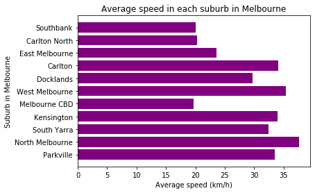

```python
plt.barh(suburb, mean_speed_list ,color = 'purple')
plt.title("Average speed in each suburb in Melbourne")
plt.ylabel("Suburb in Melbourne")
plt.xlabel("Average speed (km/h)")
plt.show()
```

### A Tukey boxplot showing the distribution of vehicle class 1 (the number of short vehi- cles) within the traffic survey results.

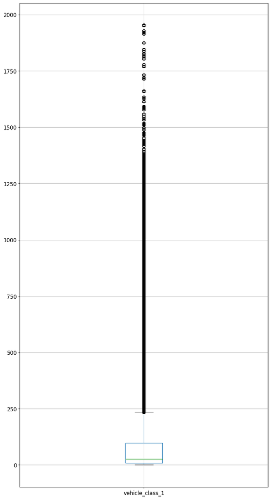

```python
boxplot = traffic.boxplot(column = 'vehicle_class_1',fontsize = 'large', grid = True, figsize = (10,20))
```

```python
traffic['vehicle_class_1'].quantile([0.25, 0.5, 0.75])
```

```
0.25     8.0
0.50    27.0
0.75    98.0
Name: vehicle_class_1, dtype: float64
```

### Comment

#### (a) From the bar chart, we could observe that North Melbourne has the highest average speed among all suburbs in Melbourne

#### (b) In our dataset, most of the number of short vehicles within traffic survey results falls between 0 and 250. With a 1st Quartile of 8.0, Median of 27 and 3rd Quartiles of 98 short vehicles (vehicle_class_1) within the traffic survey datasets. However, there are a lot of outliers.

## Q 3.2 Dimension reduction and visualisation (4 marks)

The special traffic.csv dataset contains entries from traffic.csv with some added information. Although there are fewer entries than in the original traffic.csv dataset, there are still too many to visualise efficiently. For this set of visual analysis, we wish to create a DataFrame special traffic by randomly sampling 1000 entries from the dataset special traffic.csv. The attribute idx is the identifier of a traffic survey entry and StrType is the road type of the survey entry.

### Using this special traffic DataFrame and all attributes except for StrType and idx as features:

#### a) Perform Principal Component Analysis to determine the first and second principal components of this dataset. Produce a scatter plot of the first 2 principal components, colouring the points by their StrType value. (1 mark)

#### b) Interpret the scatter plot. (1 mark)

#### c) Perform two VAT visual analyses: one on all features and the other on the two compo- nents from task Q 3.2.a (1 mark)

#### d) Interpret the two VAT plots and explain the differences. (1 mark)

```python
special_traffic = pd.read_csv('special_traffic.csv')
special_traffic.head(6)
```

|  | idx | maximum_speed | speed_limit | average_speed | vehicle_class_1 | vehicle_class_2 | vehicle_class_3 | vehicle_class_4 | vehicle_class_5 | vehicle_class_6 | vehicle_class_7 | vehicle_class_8 | vehicle_class_9 | vehicle_class_10 | vehicle_class_11 | vehicle_class_12 | vehicle_class_13 | bike | motorcycle | StrType |
| --- | --- | --- | --- | --- | --- | --- | --- | --- | --- | --- | --- | --- | --- | --- | --- | --- | --- | --- | --- | --- |
| 0 | 10459 | 36 | 50 | 30 | 12 | 0 | 0 | 0 | 0 | 0 | 0 | 0 | 0 | 0 | 0 | 0 | 0 | 0 | 0 | Council Minor |
| 1 | 14493 | 13 | 40 | 10 | 5 | 0 | 0 | 0 | 0 | 0 | 0 | 0 | 0 | 0 | 0 | 0 | 0 | 5 | 0 | Council Minor |
| 2 | 13940 | 18 | 40 | 11 | 8 | 0 | 0 | 0 | 0 | 0 | 0 | 0 | 0 | 0 | 0 | 0 | 0 | 3 | 0 | Council Minor |
| 3 | 33785 | 35 | 50 | 26 | 12 | 0 | 1 | 0 | 0 | 0 | 0 | 0 | 0 | 0 | 0 | 0 | 0 | 1 | 1 | Council Minor |
| 4 | 13341 | 18 | 40 | 15 | 1 | 0 | 0 | 2 | 0 | 0 | 0 | 0 | 0 | 0 | 0 | 0 | 0 | 0 | 0 | Council Minor |
| 5 | 40594 | 78 | 50 | 55 | 612 | 1 | 50 | 3 | 1 | 0 | 1 | 0 | 0 | 0 | 0 | 0 | 0 | 6 | 4 | Arterial |

```python
special_traffic.info()
```

```
<class 'pandas.core.frame.DataFrame'>
RangeIndex: 3680 entries, 0 to 3679
Data columns (total 20 columns):
idx                 3680 non-null int64
maximum_speed       3680 non-null int64
speed_limit         3680 non-null int64
average_speed       3680 non-null int64
vehicle_class_1     3680 non-null int64
vehicle_class_2     3680 non-null int64
vehicle_class_3     3680 non-null int64
vehicle_class_4     3680 non-null int64
vehicle_class_5     3680 non-null int64
vehicle_class_6     3680 non-null int64
vehicle_class_7     3680 non-null int64
vehicle_class_8     3680 non-null int64
vehicle_class_9     3680 non-null int64
vehicle_class_10    3680 non-null int64
vehicle_class_11    3680 non-null int64
vehicle_class_12    3680 non-null int64
vehicle_class_13    3680 non-null int64
bike                3680 non-null int64
motorcycle          3680 non-null int64
StrType             3680 non-null object
dtypes: int64(19), object(1)
memory usage: 575.1+ KB
```

```python
# drop column idx since it has no value in the analysis
special_traffic.drop(columns = ['idx'], axis = 1, inplace = True)
special_traffic.head(5)
```

|  | maximum_speed | speed_limit | average_speed | vehicle_class_1 | vehicle_class_2 | vehicle_class_3 | vehicle_class_4 | vehicle_class_5 | vehicle_class_6 | vehicle_class_7 | vehicle_class_8 | vehicle_class_9 | vehicle_class_10 | vehicle_class_11 | vehicle_class_12 | vehicle_class_13 | bike | motorcycle | StrType |
| --- | --- | --- | --- | --- | --- | --- | --- | --- | --- | --- | --- | --- | --- | --- | --- | --- | --- | --- | --- |
| 0 | 36 | 50 | 30 | 12 | 0 | 0 | 0 | 0 | 0 | 0 | 0 | 0 | 0 | 0 | 0 | 0 | 0 | 0 | Council Minor |
| 1 | 13 | 40 | 10 | 5 | 0 | 0 | 0 | 0 | 0 | 0 | 0 | 0 | 0 | 0 | 0 | 0 | 5 | 0 | Council Minor |
| 2 | 18 | 40 | 11 | 8 | 0 | 0 | 0 | 0 | 0 | 0 | 0 | 0 | 0 | 0 | 0 | 0 | 3 | 0 | Council Minor |
| 3 | 35 | 50 | 26 | 12 | 0 | 1 | 0 | 0 | 0 | 0 | 0 | 0 | 0 | 0 | 0 | 0 | 1 | 1 | Council Minor |
| 4 | 18 | 40 | 15 | 1 | 0 | 0 | 2 | 0 | 0 | 0 | 0 | 0 | 0 | 0 | 0 | 0 | 0 | 0 | Council Minor |

```python
special_traffic.info()
```

```
<class 'pandas.core.frame.DataFrame'>
RangeIndex: 3680 entries, 0 to 3679
Data columns (total 19 columns):
maximum_speed       3680 non-null int64
speed_limit         3680 non-null int64
average_speed       3680 non-null int64
vehicle_class_1     3680 non-null int64
vehicle_class_2     3680 non-null int64
vehicle_class_3     3680 non-null int64
vehicle_class_4     3680 non-null int64
vehicle_class_5     3680 non-null int64
vehicle_class_6     3680 non-null int64
vehicle_class_7     3680 non-null int64
vehicle_class_8     3680 non-null int64
vehicle_class_9     3680 non-null int64
vehicle_class_10    3680 non-null int64
vehicle_class_11    3680 non-null int64
vehicle_class_12    3680 non-null int64
vehicle_class_13    3680 non-null int64
bike                3680 non-null int64
motorcycle          3680 non-null int64
StrType             3680 non-null object
dtypes: int64(18), object(1)
memory usage: 546.3+ KB
```

#### For this set of visual analysis, we wish to create a DataFrame special traffic by randomly sampling 1000 entries from the dataset special traffic.csv.

```python
random_special_traffic = special_traffic.sample(n = 1000, random_state = 50)
random_special_traffic.head(5)
```

|  | maximum_speed | speed_limit | average_speed | vehicle_class_1 | vehicle_class_2 | vehicle_class_3 | vehicle_class_4 | vehicle_class_5 | vehicle_class_6 | vehicle_class_7 | vehicle_class_8 | vehicle_class_9 | vehicle_class_10 | vehicle_class_11 | vehicle_class_12 | vehicle_class_13 | bike | motorcycle | StrType |
| --- | --- | --- | --- | --- | --- | --- | --- | --- | --- | --- | --- | --- | --- | --- | --- | --- | --- | --- | --- |
| 2370 | 44 | 50 | 34 | 6 | 0 | 5 | 0 | 0 | 0 | 0 | 0 | 0 | 0 | 0 | 0 | 0 | 0 | 0 | Council Minor |
| 2602 | 52 | 50 | 32 | 941 | 3 | 11 | 1 | 1 | 0 | 0 | 0 | 0 | 0 | 0 | 0 | 0 | 6 | 8 | Arterial |
| 570 | 58 | 50 | 33 | 1280 | 19 | 35 | 22 | 5 | 0 | 13 | 5 | 7 | 0 | 0 | 1 | 0 | 59 | 35 | Arterial |
| 293 | 77 | 50 | 35 | 670 | 0 | 30 | 3 | 0 | 1 | 0 | 0 | 0 | 0 | 0 | 0 | 0 | 6 | 11 | Arterial |
| 2263 | 36 | 50 | 23 | 8 | 0 | 3 | 0 | 0 | 0 | 0 | 0 | 0 | 0 | 0 | 0 | 0 | 0 | 0 | Council Minor |

Check if is has random sample 1000 entries from the dataset special_traffic.csv

```python
random_special_traffic.info()
```

```
<class 'pandas.core.frame.DataFrame'>
Int64Index: 1000 entries, 2370 to 815
Data columns (total 19 columns):
maximum_speed       1000 non-null int64
speed_limit         1000 non-null int64
average_speed       1000 non-null int64
vehicle_class_1     1000 non-null int64
vehicle_class_2     1000 non-null int64
vehicle_class_3     1000 non-null int64
vehicle_class_4     1000 non-null int64
vehicle_class_5     1000 non-null int64
vehicle_class_6     1000 non-null int64
vehicle_class_7     1000 non-null int64
vehicle_class_8     1000 non-null int64
vehicle_class_9     1000 non-null int64
vehicle_class_10    1000 non-null int64
vehicle_class_11    1000 non-null int64
vehicle_class_12    1000 non-null int64
vehicle_class_13    1000 non-null int64
bike                1000 non-null int64
motorcycle          1000 non-null int64
StrType             1000 non-null object
dtypes: int64(18), object(1)
memory usage: 156.2+ KB
```

```python
# Standardize the dataset’s features onto unit scale (mean = 0 and variance = 1)
# which is a requirement for the optimal performance of many machine learning algorithms

from sklearn.preprocessing import StandardScaler
# Separate out the features

features = ['maximum_speed', 'speed_limit', 'average_speed', 'vehicle_class_1', 'vehicle_class_2' ,'vehicle_class_3',
            'vehicle_class_4', 'vehicle_class_5', 'vehicle_class_6' , 'vehicle_class_7' ,
            'vehicle_class_8' ,'vehicle_class_9' , 'vehicle_class_10' , 'vehicle_class_11' , 'vehicle_class_12',
            'vehicle_class_13', 'bike' , 'motorcycle']

x = random_special_traffic.loc[:, features].values
# Separate out the StrType
y = random_special_traffic.loc[:,['StrType']].values

#Standardizing the features
x = StandardScaler().fit_transform(x)
```

```python
from sklearn.decomposition import PCA

pca = PCA(n_components = 2)

principalComponents = pca.fit_transform(x)

principalDf = pd.DataFrame(data = principalComponents, columns = ['principal component 1' , 'principal component 2'])
```

```python
special_traffic['StrType'].unique()
```

```
array(['Council Minor', 'Arterial'], dtype=object)
```

```python
# Concatenating DataFrame along axis = 1. finalDf is the final DataFrame before plotting the data.
finalDf = pd.concat([principalDf, random_special_traffic[['StrType']]], axis = 1)
```

### a) Perform Principal Component Analysis to determine the first and second principal components of this dataset. Produce a scatter plot of the first 2 principal components, colouring the points by their StrType value. (1 mark)

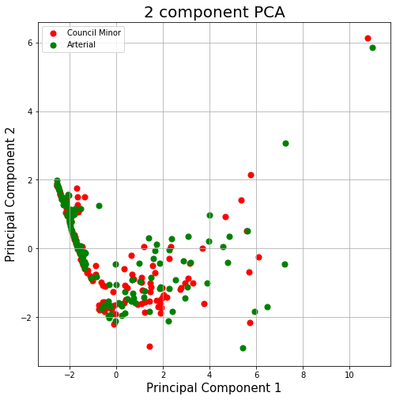

```python
fig = plt.figure(figsize = (8,8))
ax = fig.add_subplot(1,1,1)
ax.set_xlabel('Principal Component 1', fontsize = 15)
ax.set_ylabel('Principal Component 2', fontsize = 15)
ax.set_title('2 component PCA', fontsize = 20)
targets = ['Council Minor', 'Arterial']
colors = ['r', 'g']
for target, color in zip(targets,colors):
    indicesToKeep = finalDf['StrType'] == target
    ax.scatter(finalDf.loc[indicesToKeep, 'principal component 1']
               , finalDf.loc[indicesToKeep, 'principal component 2']
               , c = color
               , s = 50)
ax.legend(targets)
ax.grid()
```

The explained variane informs about the amount of information (variance) can be attributed to each of the principla components. By using explained_variance*ratio*, we can observe that the first principal compnent contains 38.57% of the variance and the second principal components contains 12.15% of the variance. Together, the two components contains 50.72% of the information

```python
pca.explained_variance_ratio_
```

```
array([0.3857307 , 0.12151037])
```

### Interpret the scatter plot

- For Arterial, there is a cluster formed between -1 to 2 for Principal Component 2 and between -2.5 to -1.5 for Principal Component 1
- For Council Minor, there some unclear cluster formed between -1.5 to 4 in the Principal Component 1 axis and no cluster formed after 4.

```python
special_traffic.head(1)
```

|  | maximum_speed | speed_limit | average_speed | vehicle_class_1 | vehicle_class_2 | vehicle_class_3 | vehicle_class_4 | vehicle_class_5 | vehicle_class_6 | vehicle_class_7 | vehicle_class_8 | vehicle_class_9 | vehicle_class_10 | vehicle_class_11 | vehicle_class_12 | vehicle_class_13 | bike | motorcycle | StrType |
| --- | --- | --- | --- | --- | --- | --- | --- | --- | --- | --- | --- | --- | --- | --- | --- | --- | --- | --- | --- |
| 0 | 36 | 50 | 30 | 12 | 0 | 0 | 0 | 0 | 0 | 0 | 0 | 0 | 0 | 0 | 0 | 0 | 0 | 0 | Council Minor |

```python
#retain a copy with only these columns without StrType
special_traffic2 = random_special_traffic[['maximum_speed', 'speed_limit', 'average_speed', 'vehicle_class_1', 'vehicle_class_2' ,'vehicle_class_3',
            'vehicle_class_4', 'vehicle_class_5', 'vehicle_class_6' , 'vehicle_class_7' ,
            'vehicle_class_8' ,'vehicle_class_9' , 'vehicle_class_10' , 'vehicle_class_11' , 'vehicle_class_12',
            'vehicle_class_13', 'bike' , 'motorcycle']]
special_traffic2.head(3)
```

|  | maximum_speed | speed_limit | average_speed | vehicle_class_1 | vehicle_class_2 | vehicle_class_3 | vehicle_class_4 | vehicle_class_5 | vehicle_class_6 | vehicle_class_7 | vehicle_class_8 | vehicle_class_9 | vehicle_class_10 | vehicle_class_11 | vehicle_class_12 | vehicle_class_13 | bike | motorcycle |
| --- | --- | --- | --- | --- | --- | --- | --- | --- | --- | --- | --- | --- | --- | --- | --- | --- | --- | --- |
| 2370 | 44 | 50 | 34 | 6 | 0 | 5 | 0 | 0 | 0 | 0 | 0 | 0 | 0 | 0 | 0 | 0 | 0 | 0 |
| 2602 | 52 | 50 | 32 | 941 | 3 | 11 | 1 | 1 | 0 | 0 | 0 | 0 | 0 | 0 | 0 | 0 | 6 | 8 |
| 570 | 58 | 50 | 33 | 1280 | 19 | 35 | 22 | 5 | 0 | 13 | 5 | 7 | 0 | 0 | 1 | 0 | 59 | 35 |

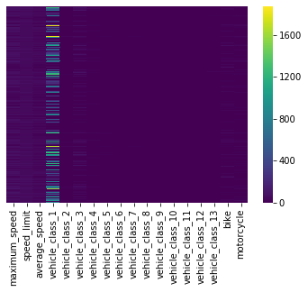

```python
####Draw heatmap of raw Special Traffic matrix#######j
sns.heatmap(special_traffic2,cmap='viridis',xticklabels=True,yticklabels=False)
plt.show()
```

### Normalize the datasets in special_traffic2 for VAT algorithm

The point of normalization is to change the observations so that they can be described as a normal distribution.

Normal distribution (Gaussian distribution), also known as the bell curve, is a specific statistical distribution where a roughly equal observations fall above and below the mean, the mean and the median are the same, and there are more observations closer to the mean.

```python
normalized_data =((special_traffic2 - special_traffic2.mean()) / (special_traffic2.max() - special_traffic2.min()))
normalized_data
```

|  | maximum_speed | speed_limit | average_speed | vehicle_class_1 | vehicle_class_2 | vehicle_class_3 | vehicle_class_4 | vehicle_class_5 | vehicle_class_6 | vehicle_class_7 | vehicle_class_8 | vehicle_class_9 | vehicle_class_10 | vehicle_class_11 | vehicle_class_12 | vehicle_class_13 | bike | motorcycle |
| --- | --- | --- | --- | --- | --- | --- | --- | --- | --- | --- | --- | --- | --- | --- | --- | --- | --- | --- |
| 2370 | -0.023870 | 0.0745 | 0.055370 | -0.134985 | -0.035875 | -0.043812 | -0.074778 | -0.053187 | -0.040286 | -0.011036 | -0.023 | -0.055714 | -0.019143 | -0.003 | -0.003 | -0.017687 | -0.082535 | -0.052936 |
| 2602 | 0.034101 | 0.0745 | 0.018333 | 0.363682 | 0.057875 | -0.007448 | -0.037741 | 0.009313 | -0.040286 | -0.011036 | -0.023 | -0.055714 | -0.019143 | -0.003 | -0.003 | -0.017687 | 0.001972 | 0.049628 |
| 570 | 0.077580 | 0.0745 | 0.036852 | 0.544482 | 0.557875 | 0.138006 | 0.740037 | 0.259313 | -0.040286 | 0.453250 | 0.977 | 0.944286 | -0.019143 | -0.003 | 0.997 | -0.017687 | 0.748451 | 0.395782 |
| 293 | 0.215261 | 0.0745 | 0.073889 | 0.219149 | -0.035875 | 0.107703 | 0.036333 | -0.053187 | 0.102571 | -0.011036 | -0.023 | -0.055714 | -0.019143 | -0.003 | -0.003 | -0.017687 | 0.001972 | 0.088090 |
| 2263 | -0.081841 | 0.0745 | -0.148333 | -0.133918 | -0.035875 | -0.055933 | -0.074778 | -0.053187 | -0.040286 | -0.011036 | -0.023 | -0.055714 | -0.019143 | -0.003 | -0.003 | -0.017687 | -0.082535 | -0.052936 |
| 1989 | 0.229754 | 0.0745 | 0.499815 | -0.097651 | -0.035875 | -0.055933 | -0.074778 | -0.053187 | -0.040286 | -0.011036 | -0.023 | 0.087143 | -0.019143 | -0.003 | -0.003 | -0.017687 | -0.068451 | -0.027295 |
| 2571 | -0.190536 | -0.6755 | -0.352037 | -0.125918 | -0.035875 | -0.074115 | -0.074778 | -0.053187 | -0.040286 | -0.011036 | -0.023 | -0.055714 | -0.019143 | -0.003 | -0.003 | -0.017687 | -0.082535 | -0.052936 |
| 1036 | -0.270246 | -0.1755 | -0.444630 | -0.133385 | -0.035875 | -0.068055 | -0.074778 | -0.053187 | -0.040286 | -0.011036 | -0.023 | -0.055714 | -0.019143 | -0.003 | -0.003 | -0.017687 | 0.030141 | -0.052936 |
| 1148 | 0.186275 | 0.0745 | -0.037222 | 0.525815 | 0.245375 | 0.447097 | 0.221519 | 0.009313 | -0.040286 | -0.011036 | -0.023 | 0.372857 | -0.019143 | -0.003 | -0.003 | -0.017687 | -0.012113 | 0.165013 |
| 2061 | 0.150043 | 0.0745 | 0.055370 | 0.270349 | 0.026625 | 0.077400 | -0.000704 | -0.053187 | 0.245429 | -0.011036 | -0.023 | 0.087143 | -0.019143 | -0.003 | -0.003 | -0.017687 | 0.016056 | 0.049628 |
| 2361 | -0.205029 | -0.6755 | -0.240926 | -0.136051 | -0.035875 | -0.074115 | -0.074778 | -0.053187 | -0.040286 | -0.011036 | -0.023 | -0.055714 | -0.019143 | -0.003 | -0.003 | -0.017687 | -0.082535 | -0.052936 |
| 3582 | -0.241261 | -0.1755 | -0.389074 | -0.134451 | -0.035875 | -0.074115 | -0.074778 | -0.053187 | -0.040286 | -0.011036 | -0.023 | -0.055714 | -0.019143 | -0.003 | -0.003 | -0.017687 | -0.026197 | -0.052936 |
| 3002 | 0.142797 | 0.3245 | 0.277593 | 0.065015 | -0.035875 | 0.083461 | 0.036333 | 0.071813 | -0.040286 | -0.011036 | -0.023 | 0.087143 | -0.019143 | -0.003 | -0.003 | -0.017687 | -0.054366 | -0.001654 |
| 90 | 0.222507 | 0.3245 | 0.333148 | 0.191949 | -0.004625 | 0.210733 | 0.777074 | 0.321813 | 0.245429 | -0.011036 | 0.177 | 0.230000 | -0.019143 | -0.003 | -0.003 | -0.017687 | 0.368169 | 0.011167 |
| 2912 | 0.121058 | 0.0745 | 0.240556 | 0.076215 | -0.004625 | 0.016794 | -0.000704 | -0.053187 | 0.245429 | 0.024679 | -0.023 | -0.055714 | -0.019143 | -0.003 | -0.003 | 0.169813 | 0.001972 | -0.040115 |
| 1292 | 0.142797 | 0.0745 | 0.166481 | 0.259682 | 0.026625 | -0.007448 | 0.073370 | 0.009313 | 0.102571 | -0.011036 | 0.177 | -0.055714 | -0.019143 | -0.003 | -0.003 | 0.169813 | 0.142817 | 0.177833 |
| 648 | -0.045609 | 0.0745 | -0.129815 | -0.131251 | -0.035875 | -0.061994 | -0.074778 | -0.053187 | -0.040286 | -0.011036 | -0.023 | -0.055714 | -0.019143 | -0.003 | -0.003 | -0.017687 | -0.054366 | -0.014474 |
| 1072 | 0.142797 | 0.0745 | 0.203519 | 0.141282 | 0.089125 | 0.168309 | 0.036333 | -0.053187 | 0.102571 | 0.024679 | -0.023 | -0.055714 | -0.019143 | -0.003 | -0.003 | 0.294812 | 0.128732 | 0.011167 |
| 1715 | -0.226768 | -0.1755 | -0.315000 | -0.136585 | -0.035875 | -0.074115 | -0.074778 | -0.053187 | -0.040286 | -0.011036 | -0.023 | -0.055714 | -0.019143 | -0.003 | -0.003 | -0.017687 | -0.054366 | -0.040115 |
| 571 | 0.200768 | 0.3245 | 0.259074 | 0.362082 | -0.004625 | 0.392552 | 0.406704 | 0.259313 | -0.040286 | 0.024679 | -0.023 | 0.515714 | 0.552286 | -0.003 | -0.003 | -0.017687 | -0.026197 | 0.075269 |
| 1418 | 0.171783 | 0.3245 | 0.185000 | 0.397815 | 0.089125 | 0.356188 | 0.517815 | 0.321813 | 0.102571 | -0.011036 | -0.023 | -0.055714 | 0.123714 | -0.003 | -0.003 | -0.017687 | -0.012113 | 0.139372 |
| 2830 | -0.183290 | -0.6755 | -0.352037 | -0.136585 | -0.035875 | -0.068055 | -0.074778 | -0.053187 | -0.040286 | -0.011036 | -0.023 | -0.055714 | -0.019143 | -0.003 | -0.003 | -0.017687 | -0.082535 | -0.052936 |
| 1465 | 0.164536 | 0.3245 | 0.296111 | 0.199949 | 0.057875 | 0.410733 | 0.221519 | 0.259313 | 0.102571 | 0.060393 | -0.023 | 0.658571 | 0.123714 | -0.003 | -0.003 | -0.017687 | -0.054366 | 0.011167 |
| 703 | -0.103580 | 0.0745 | 0.036852 | -0.137651 | -0.035875 | -0.074115 | -0.074778 | -0.053187 | -0.040286 | -0.011036 | -0.023 | -0.055714 | -0.019143 | -0.003 | -0.003 | -0.017687 | -0.082535 | -0.052936 |
| 1493 | 0.208014 | 0.0745 | 0.407222 | 0.102882 | -0.004625 | -0.019570 | 0.073370 | 0.071813 | -0.040286 | -0.011036 | -0.023 | -0.055714 | -0.019143 | -0.003 | -0.003 | -0.017687 | 0.086479 | 0.088090 |
| 650 | 0.171783 | 0.0745 | 0.259074 | 0.305015 | 0.057875 | -0.013509 | 0.036333 | -0.053187 | 0.102571 | -0.011036 | -0.023 | -0.055714 | -0.019143 | -0.003 | -0.003 | -0.017687 | 0.325915 | 0.100910 |
| 1210 | -0.234014 | 0.0745 | -0.315000 | -0.137118 | -0.035875 | -0.074115 | -0.074778 | -0.053187 | -0.040286 | -0.011036 | -0.023 | -0.055714 | -0.019143 | -0.003 | -0.003 | -0.017687 | -0.082535 | -0.052936 |
| 2133 | -0.118072 | -0.1755 | -0.111296 | -0.137118 | -0.035875 | -0.074115 | -0.074778 | -0.053187 | -0.040286 | -0.011036 | -0.023 | -0.055714 | -0.019143 | -0.003 | -0.003 | -0.017687 | -0.082535 | -0.040115 |
| 1153 | -0.197783 | -0.1755 | -0.259444 | -0.136585 | -0.035875 | -0.074115 | -0.074778 | -0.053187 | -0.040286 | -0.011036 | -0.023 | -0.055714 | -0.019143 | -0.003 | -0.003 | -0.017687 | -0.082535 | -0.052936 |
| 3579 | -0.183290 | -0.5505 | -0.203889 | -0.136585 | -0.035875 | -0.074115 | -0.074778 | -0.053187 | -0.040286 | -0.011036 | -0.023 | -0.055714 | -0.019143 | -0.003 | -0.003 | -0.017687 | -0.082535 | -0.052936 |
| ... | ... | ... | ... | ... | ... | ... | ... | ... | ... | ... | ... | ... | ... | ... | ... | ... | ... | ... |
| 3230 | -0.291986 | -0.1755 | -0.444630 | -0.137651 | -0.035875 | -0.074115 | -0.074778 | -0.053187 | -0.040286 | -0.011036 | -0.023 | -0.055714 | -0.019143 | -0.003 | -0.003 | -0.017687 | -0.082535 | -0.052936 |
| 1806 | -0.183290 | -0.1755 | -0.333519 | -0.122718 | -0.004625 | -0.074115 | -0.074778 | -0.053187 | -0.040286 | -0.011036 | -0.023 | -0.055714 | -0.019143 | -0.003 | -0.003 | -0.017687 | 0.114648 | -0.027295 |
| 2683 | -0.067348 | 0.0745 | -0.222407 | -0.131251 | -0.035875 | -0.074115 | -0.074778 | -0.053187 | -0.040286 | -0.011036 | -0.023 | -0.055714 | -0.019143 | -0.003 | -0.003 | -0.017687 | -0.082535 | -0.052936 |
| 754 | -0.226768 | -0.1755 | -0.296481 | -0.136051 | -0.035875 | -0.074115 | -0.074778 | -0.053187 | -0.040286 | -0.011036 | -0.023 | -0.055714 | -0.019143 | -0.003 | -0.003 | -0.017687 | -0.082535 | -0.052936 |
| 2313 | 0.200768 | 0.3245 | 0.296111 | 0.413282 | 0.089125 | 0.174370 | -0.000704 | 0.134313 | -0.040286 | 0.024679 | -0.023 | 0.087143 | -0.019143 | -0.003 | -0.003 | -0.017687 | -0.054366 | 0.165013 |
| 143 | -0.016623 | 0.0745 | -0.111296 | -0.136051 | -0.035875 | -0.068055 | -0.074778 | -0.053187 | -0.040286 | -0.011036 | -0.023 | -0.055714 | -0.019143 | -0.003 | -0.003 | -0.017687 | -0.082535 | -0.052936 |
| 2986 | -0.226768 | -0.1755 | -0.333519 | -0.133918 | -0.035875 | -0.074115 | -0.074778 | -0.053187 | -0.040286 | -0.011036 | -0.023 | -0.055714 | -0.019143 | -0.003 | -0.003 | -0.017687 | -0.026197 | -0.052936 |
| 2807 | 0.063087 | 0.0745 | -0.000185 | 0.603682 | 0.120375 | 0.222855 | 0.295593 | 0.259313 | 0.102571 | 0.060393 | -0.023 | 0.515714 | -0.019143 | -0.003 | -0.003 | -0.017687 | 0.030141 | 0.165013 |
| 1379 | -0.197783 | -0.1755 | -0.296481 | -0.132318 | -0.035875 | -0.074115 | -0.074778 | -0.053187 | -0.040286 | -0.011036 | -0.023 | -0.055714 | -0.019143 | -0.003 | -0.003 | -0.017687 | -0.068451 | -0.052936 |
| 2513 | -0.190536 | 0.0745 | -0.185370 | -0.137651 | -0.035875 | -0.074115 | -0.074778 | -0.053187 | -0.040286 | -0.011036 | -0.023 | -0.055714 | -0.019143 | -0.003 | -0.003 | -0.017687 | -0.082535 | -0.052936 |
| 1866 | 0.200768 | 0.0745 | 0.444259 | -0.042718 | -0.035875 | -0.043812 | 0.073370 | -0.053187 | -0.040286 | -0.011036 | -0.023 | -0.055714 | -0.019143 | -0.003 | -0.003 | -0.017687 | 0.001972 | -0.014474 |
| 3175 | -0.190536 | -0.1755 | -0.277963 | -0.133385 | -0.035875 | -0.074115 | -0.074778 | -0.053187 | -0.040286 | -0.011036 | -0.023 | -0.055714 | -0.019143 | -0.003 | -0.003 | -0.017687 | -0.082535 | -0.052936 |
| 3160 | -0.226768 | -0.6755 | -0.277963 | -0.137651 | -0.035875 | -0.074115 | -0.074778 | -0.053187 | -0.040286 | -0.011036 | -0.023 | -0.055714 | -0.019143 | -0.003 | -0.003 | -0.017687 | -0.082535 | -0.052936 |
| 208 | 0.084826 | 0.0745 | -0.129815 | 0.161015 | 0.089125 | 0.095582 | -0.037741 | -0.053187 | 0.245429 | -0.011036 | -0.023 | -0.055714 | -0.019143 | -0.003 | -0.003 | -0.017687 | 0.001972 | 0.126551 |
| 2523 | -0.154304 | -0.1755 | -0.315000 | -0.130185 | -0.035875 | -0.074115 | -0.074778 | -0.053187 | -0.040286 | -0.011036 | -0.023 | -0.055714 | -0.019143 | -0.003 | -0.003 | -0.017687 | -0.068451 | -0.014474 |
| 3270 | -0.248507 | -0.1755 | -0.389074 | -0.137118 | -0.035875 | -0.068055 | -0.074778 | -0.053187 | -0.040286 | -0.011036 | -0.023 | -0.055714 | -0.019143 | -0.003 | -0.003 | -0.017687 | -0.082535 | -0.052936 |
| 1300 | 0.092072 | 0.0745 | 0.129444 | -0.099251 | -0.035875 | -0.037752 | -0.074778 | -0.053187 | -0.040286 | -0.011036 | -0.023 | -0.055714 | -0.019143 | -0.003 | -0.003 | -0.017687 | -0.068451 | -0.052936 |
| 2765 | -0.190536 | -0.5505 | -0.240926 | -0.137118 | -0.035875 | -0.074115 | -0.074778 | -0.053187 | -0.040286 | -0.011036 | -0.023 | -0.055714 | -0.019143 | -0.003 | -0.003 | -0.017687 | -0.082535 | -0.052936 |
| 462 | 0.121058 | 0.0745 | 0.166481 | 0.194082 | 0.057875 | 0.010733 | -0.074778 | -0.053187 | -0.040286 | -0.011036 | -0.023 | -0.055714 | -0.019143 | -0.003 | -0.003 | 0.294812 | 0.142817 | 0.075269 |
| 655 | -0.176043 | -0.1755 | -0.296481 | -0.131785 | -0.035875 | -0.074115 | -0.074778 | 0.009313 | -0.040286 | -0.011036 | -0.023 | -0.055714 | -0.019143 | -0.003 | -0.003 | -0.017687 | 0.086479 | -0.040115 |
| 166 | -0.263000 | -0.1755 | -0.407593 | -0.133385 | -0.035875 | -0.074115 | -0.074778 | -0.053187 | -0.040286 | -0.011036 | -0.023 | -0.055714 | -0.019143 | -0.003 | -0.003 | -0.017687 | 0.044225 | -0.052936 |
| 1091 | 0.237000 | 0.3245 | 0.333148 | 0.161549 | 0.026625 | 0.156188 | 0.703000 | 0.196813 | -0.040286 | -0.011036 | 0.177 | 0.372857 | 0.266571 | -0.003 | -0.003 | -0.017687 | 0.227324 | 0.023987 |
| 1309 | 0.077580 | 0.0745 | -0.037222 | 0.346082 | 0.245375 | 0.010733 | 0.814111 | 0.009313 | 0.388286 | 0.060393 | -0.023 | 0.087143 | 0.123714 | 0.197 | -0.003 | -0.017687 | 0.156901 | 0.523987 |
| 1403 | 0.323957 | 0.0745 | 0.481296 | 0.059149 | -0.004625 | 0.077400 | -0.037741 | -0.053187 | -0.040286 | -0.011036 | -0.023 | -0.055714 | -0.019143 | -0.003 | -0.003 | -0.017687 | -0.068451 | 0.023987 |
| 2945 | 0.070333 | 0.0745 | 0.036852 | 0.509815 | 0.120375 | 0.198612 | 0.110407 | 0.259313 | -0.040286 | -0.011036 | 0.177 | 0.087143 | -0.019143 | -0.003 | -0.003 | -0.017687 | -0.068451 | 0.126551 |
| 928 | 0.200768 | 0.0745 | 0.185000 | 0.166349 | 0.089125 | 0.059218 | -0.000704 | -0.053187 | 0.102571 | -0.011036 | -0.023 | -0.055714 | -0.019143 | -0.003 | -0.003 | 0.544813 | 0.185070 | 0.049628 |
| 1112 | -0.212275 | -0.1755 | -0.370556 | -0.134985 | -0.035875 | -0.074115 | -0.074778 | -0.053187 | -0.040286 | -0.011036 | -0.023 | -0.055714 | -0.019143 | -0.003 | -0.003 | -0.017687 | -0.012113 | -0.052936 |
| 1608 | -0.263000 | -0.1755 | -0.426111 | -0.131251 | -0.035875 | -0.074115 | -0.074778 | -0.053187 | -0.040286 | -0.011036 | -0.023 | -0.055714 | -0.019143 | -0.003 | -0.003 | -0.017687 | 0.086479 | -0.052936 |
| 189 | -0.270246 | -0.1755 | -0.463148 | -0.131251 | -0.035875 | -0.068055 | -0.074778 | -0.053187 | -0.040286 | -0.011036 | -0.023 | -0.055714 | -0.019143 | -0.003 | -0.003 | -0.017687 | 0.100563 | -0.052936 |
| 815 | 0.323957 | 0.3245 | 0.314630 | 0.266615 | 0.057875 | 0.089521 | 0.147444 | 0.009313 | -0.040286 | -0.011036 | -0.023 | -0.055714 | -0.019143 | -0.003 | -0.003 | -0.017687 | -0.068451 | 0.062449 |

1000 rows × 18 columns

```python
normalized_data.min()
```

```
maximum_speed      -0.299232
speed_limit        -0.675500
average_speed      -0.481667
vehicle_class_1    -0.138185
vehicle_class_2    -0.035875
vehicle_class_3    -0.074115
vehicle_class_4    -0.074778
vehicle_class_5    -0.053187
vehicle_class_6    -0.040286
vehicle_class_7    -0.011036
vehicle_class_8    -0.023000
vehicle_class_9    -0.055714
vehicle_class_10   -0.019143
vehicle_class_11   -0.003000
vehicle_class_12   -0.003000
vehicle_class_13   -0.017687
bike               -0.082535
motorcycle         -0.052936
dtype: float64
```

```python
normalized_data.max()
```

```
maximum_speed       0.700768
speed_limit         0.324500
average_speed       0.518333
vehicle_class_1     0.861815
vehicle_class_2     0.964125
vehicle_class_3     0.925885
vehicle_class_4     0.925222
vehicle_class_5     0.946813
vehicle_class_6     0.959714
vehicle_class_7     0.988964
vehicle_class_8     0.977000
vehicle_class_9     0.944286
vehicle_class_10    0.980857
vehicle_class_11    0.997000
vehicle_class_12    0.997000
vehicle_class_13    0.982313
bike                0.917465
motorcycle          0.947064
dtype: float64
```

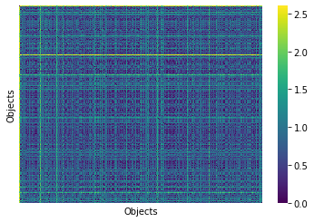

```python
import seaborn as sns
import numpy as np
import math,random
from scipy.spatial.distance import pdist, squareform
import pandas as pd
import matplotlib.pyplot as plt
%matplotlib inline

####Visualise the dissimilarity matrix for Special Traffic using a heatmap (without applying VAT)####
special_traffic3 = normalized_data.copy().values
# np.random.shuffle(special_traffic3)   ####randomise the order of rows (objects)
sq = squareform(pdist(special_traffic3))   ###commpute the dissimilarity matrix
ax=sns.heatmap(sq,cmap='viridis',xticklabels=False,yticklabels=False)
ax.set(xlabel='Objects', ylabel='Objects')
plt.show()
```

```python
special_traffic2['vehicle_class_2'].isnull().sum()
```

```
0
```

### Perform VAT visual analyses: one on all features

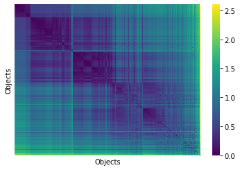

```python
#####Apply VAT Algorithm to normalized_data dataset and visualise using heatmap########
RV, C, I = VAT(normalized_data)
x=sns.heatmap(RV,cmap='viridis',xticklabels=False,yticklabels=False)
x.set(xlabel='Objects', ylabel='Objects')
plt.show()
```

```python
x = normalized_data
```

```python
from sklearn.decomposition import PCA

pca = PCA(n_components = 2)

principalComponents = pca.fit_transform(x)

principalDf = pd.DataFrame(data = principalComponents, columns = ['principal component 1' , 'principal component 2'])
```

### Perform VAT visual analysis: two components from task Q 3.2.a

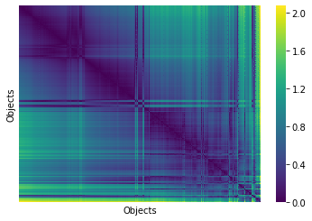

```python
#####Apply VAT Algorithm to Special Traffic dataset and visualise using heatmap########
RV, C, I = VAT(principalComponents)
x=sns.heatmap(RV,cmap='viridis',xticklabels=False,yticklabels=False)
x.set(xlabel='Objects', ylabel='Objects')
plt.show()
```

### d) Interpret the two VAT plots and explain the differences. (1 mark)

- For the VAT plots with all features, the clusters formed are not clear and hard to visualize but we could guess there are 3 formed.
- For the VAT plots using PCA, there is 4 clusters formed. Hence, it is a better visualization than the former

## Q 3.3 Clustering and visualisation(4 marks)

Perform K-means clustering on all data in the special traffic DataFrame using all at- tributes except for StrType and idx as features.

a Recall that the SSE (sum of squared errors) can be used to measure the quality of clustering. The SSE is the sum of distances of objects from their cluster centroids:

Produce a plot of SSE vs the number of clusters k as you vary the number of clusters. Use the ‘elbow method’ to identify the optimal value of k from your plot. Is this expected given your previous results in Q3.2? Why or why not? (1.5 marks)

b Perform K-means clustering on the data for k = 3. Show the size of each cluster with a bar plot. (0.5 marks)

We are interested in knowing if the model groups data well based on the attribute StrType.

c Suggest a plot to help one visually evaluate the K-means model against the measurement statement. Justify your suggestion. (1 mark)

d Draw the suggested plot and explain your finding. (1 mark)

```python
import pandas as pd
import numpy as np
from sklearn.cluster import KMeans
from sklearn.preprocessing import LabelEncoder
from sklearn.preprocessing import MinMaxScaler
import seaborn as sns
import matplotlib.pyplot as plt
%matplotlib inline
```

```python
normalized_data.head(5)
```

|  | maximum_speed | speed_limit | average_speed | vehicle_class_1 | vehicle_class_2 | vehicle_class_3 | vehicle_class_4 | vehicle_class_5 | vehicle_class_6 | vehicle_class_7 | vehicle_class_8 | vehicle_class_9 | vehicle_class_10 | vehicle_class_11 | vehicle_class_12 | vehicle_class_13 | bike | motorcycle |
| --- | --- | --- | --- | --- | --- | --- | --- | --- | --- | --- | --- | --- | --- | --- | --- | --- | --- | --- |
| 2370 | -0.023870 | 0.0745 | 0.055370 | -0.134985 | -0.035875 | -0.043812 | -0.074778 | -0.053187 | -0.040286 | -0.011036 | -0.023 | -0.055714 | -0.019143 | -0.003 | -0.003 | -0.017687 | -0.082535 | -0.052936 |
| 2602 | 0.034101 | 0.0745 | 0.018333 | 0.363682 | 0.057875 | -0.007448 | -0.037741 | 0.009313 | -0.040286 | -0.011036 | -0.023 | -0.055714 | -0.019143 | -0.003 | -0.003 | -0.017687 | 0.001972 | 0.049628 |
| 570 | 0.077580 | 0.0745 | 0.036852 | 0.544482 | 0.557875 | 0.138006 | 0.740037 | 0.259313 | -0.040286 | 0.453250 | 0.977 | 0.944286 | -0.019143 | -0.003 | 0.997 | -0.017687 | 0.748451 | 0.395782 |
| 293 | 0.215261 | 0.0745 | 0.073889 | 0.219149 | -0.035875 | 0.107703 | 0.036333 | -0.053187 | 0.102571 | -0.011036 | -0.023 | -0.055714 | -0.019143 | -0.003 | -0.003 | -0.017687 | 0.001972 | 0.088090 |
| 2263 | -0.081841 | 0.0745 | -0.148333 | -0.133918 | -0.035875 | -0.055933 | -0.074778 | -0.053187 | -0.040286 | -0.011036 | -0.023 | -0.055714 | -0.019143 | -0.003 | -0.003 | -0.017687 | -0.082535 | -0.052936 |

A fundamental step for any unsupervised algorithm is to determine the optimal number of clusters into which the data may be clustered. The Elbow Method is one of the most popular methods to determine this optimal value of k.

From the above visualization, we can see that the optimal number of clusters should be around 3. But visualizing the data alone cannot always give the right answer. Hence we demonstrate the following steps.

We now define the following:-

Distortion: It is calculated as the average of the squared distances from the cluster centers of the respective clusters. Typically, the Euclidean distance metric is used. Inertia: It is the sum of squared distances of samples to their closest cluster center. We iterate the values of k from 1 to 9 and calculate the values of distortions for each value of k and calculate the distortion and inertia for each value of k in the given range.

K means clustering using elbow method... 0-10 need to know the range

```python
inertias = []
mapping1 = {}
K = range(1,10)

x = normalized_data.values
for k in K:
    #Building and fitting the model
    kmeanModel = KMeans(n_clusters=k).fit(x)
    kmeanModel.fit(x)

    inertias.append(kmeanModel.inertia_)

    mapping1[k] = kmeanModel.inertia_
```

```python
for key,val in mapping1.items():
    print(str(key)+' : '+str(val))
```

```
1 : 366.8799570891005
2 : 213.9455394366953
3 : 172.0841200757723
4 : 144.61288818181782
5 : 130.11300473609833
6 : 116.04835163094504
7 : 106.6966274857136
8 : 100.94629464146564
9 : 95.79495471949595
```

### Produce a plot of SSE vs the number of clusters k as you vary the number of cluster

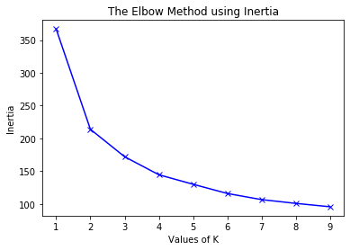

```python
plt.plot(K, inertias, 'bx-')
plt.xlabel('Values of K')
plt.ylabel('Inertia')
plt.title('The Elbow Method using Inertia')
plt.show()
```

```python
#Building and fitting the model
kmeanModel = KMeans(n_clusters=3).fit(x)
kmeanModel.fit(x)
labels = kmeanModel.labels_
y_kmeans = kmeanModel.predict(x)
```

```python
num = np.bincount(labels[labels >= 0])
x = ('Cluster1', 'Cluster 2', 'Cluster 3')
y_pos = np.arange(len(x))
```

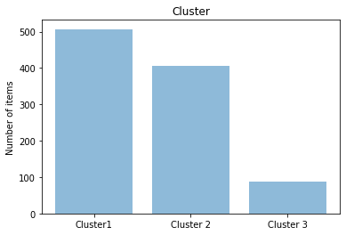

```python
plt.bar(y_pos, num, align='center', alpha=0.5)
plt.xticks(y_pos, x)
plt.ylabel('Number of items')
plt.title('Cluster')

plt.show()
```

### Comment of each cluster with a bar plot from K-means clustering

- Cluster 1 has the largest amount of items, followed by Cluster 2 and Cluster 3
- Since, if we look back into our VAT plot, Cluster 1 is the most obvious which means it has the largest amount of items.

### We are interested in knowing if the model groups data well based on the attribute StrType.

#### c Suggest a plot to help one visually evaluate the K-means model against the measurement statement. Justify your suggestion. (1 mark)

- We can use a scatterplot in order to evaluate the K means model that can allow us to model groups data well based on the attribute StType
- This is because using scatterplot, we can find the centroid of each cluster, hence the further the separation away of each centroid from each other, the more likely it has 2 category.

As expected, we use a visualisation method (a plot) to evaluate how well the clusters created by the model (from Q3.3b without StrType attribute) match StrType categories. (How well does the clustering separate the data by StrType values?)

```python
x = normalized_data.values
kmeans = KMeans(n_clusters=3)
kmeans.fit(x)
y_kmeans = kmeans.predict(x)
```

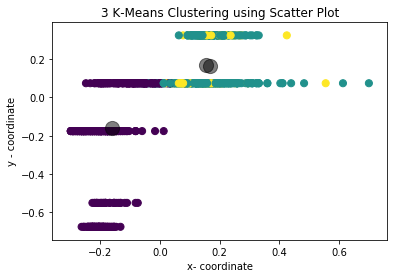

```python
plt.scatter(x[:, 0], x[:, 1], c=y_kmeans, s=50, cmap='viridis')

centers = kmeans.cluster_centers_
plt.scatter(centers[:, 0], centers[:, 1], c='black', s=200, alpha=0.5)
plt.xlabel('x- coordinate')
plt.ylabel('y - coordinate')
plt.title('3 K-Means Clustering using Scatter Plot');
```

### Comment on Scatter plot of K-means clustering

- Based on the plot, we could see that there are 3 different clusters, each having a distinct colour.
- We could also observe that there are 3 centroids, which means 3 clusters.
- If we look carefully, there are two clusters overlapping each other hence, we could combine them together and say they are from the same category or in our context, same Street Type.
- Overall, we could see that there are two distinct centroids which means two distinct category of data. In our context, two distinct Street Type, hence it support our data which has only two StrTpe (i.e Arterial and Councill Minor)